# SUN(2,2): normal-scale EM and mgcv

This example repeats the SUN simulation and the three censoring cases in `copula_kde/copula_kde_ICD/sun_example/mysun.qmd`, using the Poisson-transform spline estimators in this project. Run `quarto render mysun.qmd` from this directory. The report requires `admvn`, `sn`, `mgcv`, `statmod`, and `knitr`.

## Point estimation

We report the **point estimate of each marginal distribution**, transform both interval endpoints using its fitted CDF and then `qnorm()`, and fit the dependence density on the **normal-score scale**. Transforming this fitted density back gives the **copula point estimate**. The CDF integration helper uses `n_draws = 1` with a single row of **fitted coefficients supplied explicitly**. This row is only a computational convenience; it is not a posterior draw. Only the point CDF and density are retained for the point estimate. Optional sampling below propagates marginal and conditional copula uncertainty when `n_draws > 1`. Setting `n_draws = 1` turns sampling off in this report and uses only the fitted point estimates.

For a marginal interval $[L_i,R_i]$, the E-step allocates observation $i$ to integration cells in proportion to their overlap with the interval and the current fitted density. The M-step fits the resulting expected counts using a penalized Poisson spline using `mgcv::bam()` with `discrete = TRUE`. The bivariate fit uses the product of the two coordinate overlaps for each observed rectangle. Smoothing parameters are selected by fREML from the initial expected counts and then held fixed during EM. Discrete `bam` also uses its fREML path for these fixed-parameter updates; smoothing is not re-estimated in the M-step. This is a working smoothing choice, not observed-data REML.

Marginal CDF integration evaluates the fitted spline basis without prediction discretization, so the CDF does not depend on how query points are batched.

For each coordinate, the dependence fit receives normal-score intervals $[\Phi^{-1}\{\widehat F_j(L_{ij})\},\Phi^{-1}\{\widehat F_j(R_{ij})\}]$. EM and the spline penalty operate on this normal scale. We fit $\widehat g(z_1,z_2)$ there and recover the copula and original-scale joint density by change of variables:

$$\widehat c(u,v)
=\frac{\widehat g\{\Phi^{-1}(u),\Phi^{-1}(v)\}}
{\phi\{\Phi^{-1}(u)\}\phi\{\Phi^{-1}(v)\}},
\qquad
\widehat f_Y(y_1,y_2)
=\widehat c\{\widehat F_1(y_1),\widehat F_2(y_2)\}
\widehat f_1(y_1)\widehat f_2(y_2).$$

The fitted normal-scale density has unit total mass under its fitting quadrature. Standard normal marginal densities are not imposed, so the back-transformed copula-scale density need not have exactly uniform margins. The reconstructed joint density therefore need not reproduce the separately fitted marginal curves exactly.

```r
# chdir lets the existing fitting file load its sibling R files.
source("../code/mgcv-joint-density.R", local = TRUE, chdir = TRUE)
source("R/mysun_helpers.R", local = TRUE)
dir.create("results", showWarnings = FALSE)
```

## Setup and simulation

The SUN(2,2) parameters, sample size, and random seed match the reference. The latent sample is used for simulation and evaluation; the density fits receive only the recorded intervals.

```r
my_params <- c(
  xi1 = 0, xi2 = 0,
  nu1 = 1, nu2 = 1,
  omega12 = 0.5,
  L11 = 0.75, L12 = 0.05,
  L21 = 0.05, L22 = 0.75,
  gamma12 = 0.9
)
my_sun_params <- admvn::make_sun22_params(my_params)
set.seed(0)
ysim <- sn::rsun(4000, dp = my_sun_params)
```

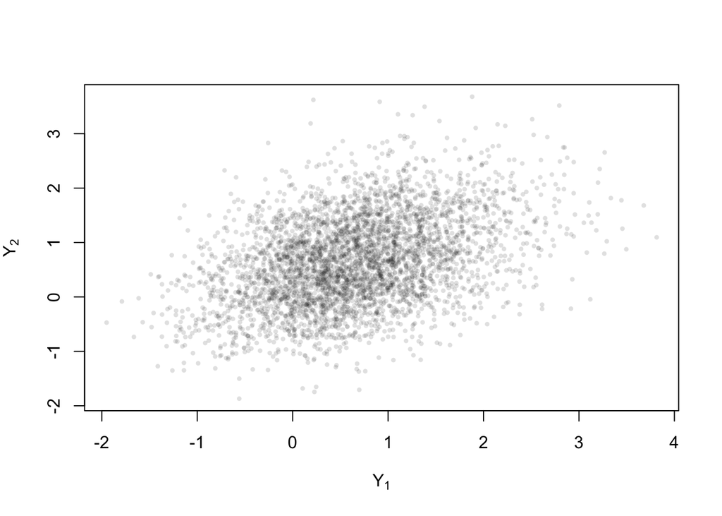

The same 4,000 latent SUN observations are used in every censoring case.

```r
plot(ysim, cex = 0.6, pch = 16, col = "#00000020",
     xlab = expression(Y[1]), ylab = expression(Y[2]))
```

### Censoring cases

Independent left and right exponential offsets have mean equal to the sample standard deviation of their coordinate, multiplied by the width scale below. Resetting seed `20260626` pairs these offsets across cases. Endpoints are rounded outward on the original data scale.

| Censoring | $Y_1$ width scale | $Y_2$ width scale | Marginal spacing | Dependence spacing |
| --- | --- | --- | --- | --- |
| Heavy | 1 | 2 | 0.2 | 0.2 |
| Intermediate | 0.5 | 1 | 0.1 | 0.1 |
| Light | 0.25 | 0.5 | 0.05 | 0.05 |

Each case uses the same rounding spacing for marginal and dependence intervals. On the normal scale, transformed endpoints are used directly; cell-overlap quadrature does not require additional endpoint rounding.

```r
case_settings <- data.frame(
  case = c("Heavy", "Intermediate", "Light"),
  width1 = c(1, 0.5, 0.25), width2 = c(2, 1, 0.5),
  marginal_spacing = c(0.2, 0.1, 0.05),
  copula_spacing = c(0.2, 0.1, 0.05)
)
marginal_data <- copula_data <- vector("list", nrow(case_settings))
names(marginal_data) <- names(copula_data) <- case_settings$case
for (i in seq_len(nrow(case_settings))) {
  settings <- case_settings[i, ]
  scales <- c(settings$width1, settings$width2)
  marginal_data[[i]] <- simulate_exponential_interval_censoring(
    ysim, seed = 20260626, round = settings$marginal_spacing, width_scale = scales)
  copula_data[[i]] <- simulate_exponential_interval_censoring(
    ysim, seed = 20260626, round = settings$copula_spacing, width_scale = scales)
}
interval_widths <- do.call(rbind, lapply(names(marginal_data), function(case) {
  data.frame(censoring = case,
    marginal_Y1 = mean(marginal_data[[case]]$right[, 1L] - marginal_data[[case]]$left[, 1L]),
    marginal_Y2 = mean(marginal_data[[case]]$right[, 2L] - marginal_data[[case]]$left[, 2L]),
    dependence_Y1 = mean(copula_data[[case]]$right[, 1L] - copula_data[[case]]$left[, 1L]),
    dependence_Y2 = mean(copula_data[[case]]$right[, 2L] - copula_data[[case]]$left[, 2L]))
}))
knitr::kable(interval_widths, digits = 3, row.names = FALSE,
             caption = "Mean observed interval widths on the original scale.")
```

Mean observed interval widths on the original scale.

| censoring | marginal_Y1 | marginal_Y2 | dependence_Y1 | dependence_Y2 |
| --- | --- | --- | --- | --- |
| Heavy | 1.816 | 3.474 | 1.816 | 3.474 |
| Intermediate | 0.907 | 1.737 | 0.907 | 1.737 |
| Light | 0.453 | 0.869 | 0.453 | 0.869 |

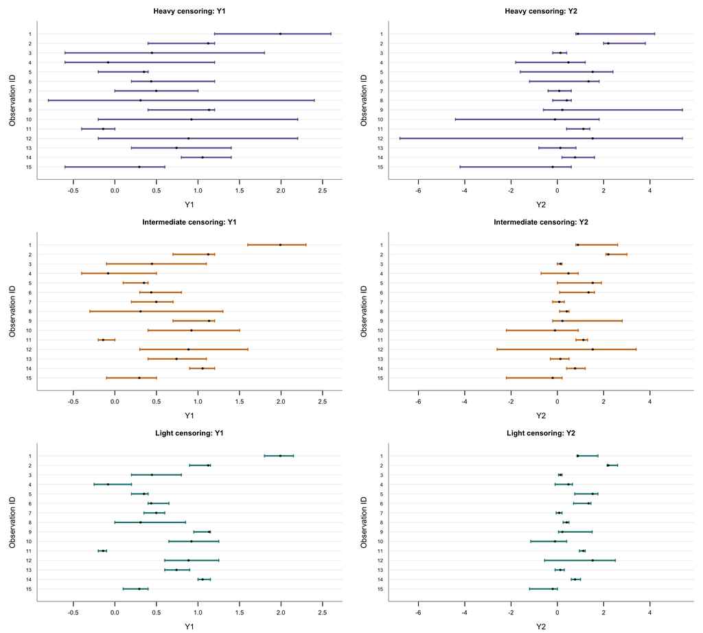

Observed marginal intervals for the same first 15 observations. Black dots show latent values for reference only.

```r
plot_mgcv_observed_intervals(marginal_data, ysim)
```

## Fit the marginals and copula

The current spline method requires finite supports. We fix both marginal computational supports at $[-8,8]$, the range used for true marginal integration in the reference. The SUN distribution itself is unbounded, so this is a finite-domain approximation. Interval contributions use their overlap with this domain. The true marginal masses in this range are reported below; supports are not chosen from latent sample extrema.

For the dependence fit, we use the normal-score domain $[-5,5]^2$. Endpoints with fitted CDF zero or one become infinite under `qnorm()`; their interval contributions are restricted to overlap with this domain. The fitted density is zero outside it, corresponding to copula coordinates outside $[\Phi(-5),\Phi(5)]$, approximately $[2.87\times10^{-7},1-2.87\times10^{-7}]$. This finite-domain approximation is separate from the ranges used for plots.

The same basis and integration sizes are used across censoring cases. `n_quad` controls numerical CDF integration, not posterior draws.

```r
supports <- list(c(-8, 8), c(-8, 8))
marginal_k <- 30L
marginal_grid <- 400L
copula_k <- c(10L, 10L)
copula_grid <- c(60L, 60L)
normal_support <- c(-5, 5)
n_quad <- 10L
em_control <- list(max_iter = 200L, tol = 1e-6)
n_draws <- 100L # Marginal draw pairs; set to 1 for point estimates only.
n_copula_draws <- 10L
interval_level <- 0.95
posterior_seed <- 20261013L
```

```r
fit_mgcv_case <- function(marginal_intervals, dependence_intervals) {
  margins <- vector("list", 2L)
  component_seconds <- numeric(3L)
  for (j in seq_len(2L)) {
    start <- proc.time()[["elapsed"]]
    est <- fit_density_mgcv(
      cbind(marginal_intervals$left[, j], marginal_intervals$right[, j]),
      support = supports[[j]], k = marginal_k, n_grid = marginal_grid,
      em_control = em_control)
    component_seconds[j] <- proc.time()[["elapsed"]] - start
    # One fixed coefficient row: integrate the fitted marginal, without sampling.
    point <- draw_marginal_cdfs_mgcv(est, n_draws = 1L, n_quad = n_quad,
      coefficients = matrix(coef(est$model), nrow = 1L))
    margins[[j]] <- point[c("fit", "cdf", "pdf")]
  }
  u <- cbind(margins[[1L]]$cdf(dependence_intervals$left[, 1L]),
             margins[[1L]]$cdf(dependence_intervals$right[, 1L]))
  v <- cbind(margins[[2L]]$cdf(dependence_intervals$left[, 2L]),
             margins[[2L]]$cdf(dependence_intervals$right[, 2L]))
  # Apply qnorm to the interval endpoints and fit once on the normal scale.
  start <- proc.time()[["elapsed"]]
  copula <- fit_copula_density_mgcv_normal(u, v, k = copula_k,
    n_grid = copula_grid, support = normal_support, em_control = em_control)
  component_seconds[3L] <- proc.time()[["elapsed"]] - start
  joint_pdf <- function(y1, y2) {
    copula$pdf(margins[[1L]]$cdf(y1), margins[[2L]]$cdf(y2)) *
      margins[[1L]]$pdf(y1) * margins[[2L]]$pdf(y2)
  }
  list(marginal_x = margins[[1L]], marginal_y = margins[[2L]],
       copula = copula, u = u, v = v, joint_pdf = joint_pdf,
       component_seconds = component_seconds)
}
```

```r
fits <- vector("list", length(marginal_data))
names(fits) <- names(marginal_data)
fit_seconds <- numeric(length(fits))
for (i in seq_along(fits)) {
  cat("Fitting ", names(fits)[i], " censoring...\n", sep = "")
  fit_seconds[i] <- system.time(
    fits[[i]] <- fit_mgcv_case(marginal_data[[i]], copula_data[[i]])
  )["elapsed"]
}
```

```
Fitting Heavy censoring...
Fitting Intermediate censoring...
Fitting Light censoring...
```

```r
fit_status <- do.call(rbind, lapply(names(fits), function(case) {
  fit <- fits[[case]]
  components <- list(fit$marginal_x$fit, fit$marginal_y$fit, fit$copula)
  do.call(rbind, lapply(seq_along(components), function(j) {
    em <- components[[j]]$em
    data.frame(censoring = case, component = c("Margin 1", "Margin 2", "Copula")[j],
      iterations = em$iterations, converged = em$converged,
      smoothing = paste(signif(em$sp, 5), collapse = ", "),
      loglik = em$loglik)
  }))
}))
knitr::kable(fit_status, digits = 3, row.names = FALSE,
             caption = "EM convergence and fixed smoothing parameters. Likelihoods concern different recorded intervals and are not cross-case model scores.")
```

EM convergence and fixed smoothing parameters. Likelihoods concern different recorded intervals and are not cross-case model scores.

| censoring | component | iterations | converged | smoothing | loglik |
| --- | --- | --- | --- | --- | --- |
| Heavy | Margin 1 | 19 | TRUE | 90.442 | -3863.742 |
| Heavy | Margin 2 | 26 | TRUE | 256.3 | -2310.618 |
| Heavy | Copula | 32 | TRUE | 1.5263, 7.0105 | -6070.151 |
| Intermediate | Margin 1 | 10 | TRUE | 30.903 | -6192.387 |
| Intermediate | Margin 2 | 16 | TRUE | 86.071 | -4107.835 |
| Intermediate | Copula | 19 | TRUE | 0.79974, 2.4668 | -10100.202 |
| Light | Margin 1 | 7 | TRUE | 17.753 | -8820.490 |
| Light | Margin 2 | 12 | TRUE | 25.95 | -6433.544 |
| Light | Copula | 11 | TRUE | 0.57612, 0.98843 | -14976.215 |

### Computation time

The table reports elapsed wall-clock seconds from this run. Component times measure each marginal or copula fitting call, including smoothing selection and all EM iterations. Copula time includes the probit transformation and normal-scale fit. Total time also includes constructing the fitted marginal CDFs and transforming the interval endpoints. Simulation, truth evaluation, and plotting are excluded. Timings depend on the machine and its current workload.

```r
fit_timing <- do.call(rbind, lapply(seq_along(fits), function(i) {
  seconds <- fits[[i]]$component_seconds
  data.frame(censoring = names(fits)[i],
    margin_1_seconds = seconds[1L], margin_2_seconds = seconds[2L],
    copula_seconds = seconds[3L], total_seconds = fit_seconds[i])
}))
knitr::kable(fit_timing, digits = 3, row.names = FALSE,
  col.names = c("Censoring", "Margin 1 (s)", "Margin 2 (s)", "Copula (s)", "Total (s)"),
  caption = "Computation time for fitting the marginal and copula point estimates.")
```

Computation time for fitting the marginal and copula point estimates.

| Censoring | Margin 1 (s) | Margin 2 (s) | Copula (s) | Total (s) |
| --- | --- | --- | --- | --- |
| Heavy | 0.319 | 0.239 | 2.220 | 3.067 |
| Intermediate | 0.104 | 0.135 | 1.631 | 1.990 |
| Light | 0.089 | 0.126 | 1.267 | 1.590 |

## True reference densities and evaluation grids

Analytical SUN densities, numerical marginal integration, and inverse-CDF interpolation provide the reference curves. The original-scale error grid is the same 120 by 120 midpoint grid as in the reference analysis. Latent sample limits enter this evaluation grid only.

```r
sun_obj <- sn::makeSUNdistr(dp = my_sun_params, name = "sun", compNames = c("Y1", "Y2"))
marg_dp <- lapply(seq_len(2L), function(j) {
  sn::marginalSUNdistr(sun_obj, comp = j, name = paste0("Y", j))@dp
})
margin_map <- lapply(marg_dp, function(dp) {
  y <- seq(-8, 8, length.out = 4001L)
  f <- as.numeric(sn::dsun(matrix(y, ncol = 1L), dp = dp))
  cdf <- c(0, cumsum(diff(y) * (head(f, -1L) + tail(f, -1L)) / 2))
  mass <- tail(cdf, 1L)
  cdf <- cdf / mass
  keep <- !duplicated(cdf)
  list(dens = approxfun(y, f, rule = 2),
       cdf = approxfun(y, cdf, rule = 2, yleft = 0, yright = 1),
       inv = approxfun(cdf[keep], y[keep], rule = 2), mass = mass)
})
knitr::kable(data.frame(margin = c("Y1", "Y2"),
  true_mass_in_support = vapply(margin_map, `[[`, numeric(1L), "mass")), digits = 10)
```

| margin | true_mass_in_support |
| --- | --- |
| Y1 | 1 |
| Y2 | 1 |

```r
true_copula_density <- function(u, v) {
  y1 <- margin_map[[1L]]$inv(u)
  y2 <- margin_map[[2L]]$inv(v)
  as.numeric(sn::dsun(cbind(y1, y2), dp = my_sun_params)) /
    (margin_map[[1L]]$dens(y1) * margin_map[[2L]]$dens(y2))
}
marginal_grids <- lapply(seq_len(2L), function(j) {
  seq(min(ysim[, j]) - 0.5 * sd(ysim[, j]),
      max(ysim[, j]) + 0.5 * sd(ysim[, j]), length.out = 501L)
})
edges_x <- seq(min(ysim[, 1L]), max(ysim[, 1L]), length.out = 121L)
edges_y <- seq(min(ysim[, 2L]), max(ysim[, 2L]), length.out = 121L)
eval_x <- head(edges_x, -1L) + diff(edges_x) / 2
eval_y <- head(edges_y, -1L) + diff(edges_y) / 2
eval_area <- diff(edges_x)[1L] * diff(edges_y)[1L]
truth_joint <- matrix(sn::dsun(as.matrix(expand.grid(eval_x, eval_y)),
  dp = my_sun_params), nrow = length(eval_x))
ug <- seq(0.01, 0.99, length.out = 41L)
truth_copula <- outer(ug, ug, true_copula_density)
```

```r
views <- lapply(names(fits), function(case) {
  fit <- fits[[case]]
  z <- if (case == "Light") seq(-2.5, 2.5, length.out = 41L) else
    seq(-3.5, 3.5, length.out = 57L)
  normal_jacobian <- outer(dnorm(z), dnorm(z))
  list(z = z, u = ug,
    true_normal = outer(pnorm(z), pnorm(z), true_copula_density) * normal_jacobian,
    normal = outer(z, z, fit$copula$normal_pdf),
    copula = outer(ug, ug, fit$copula$pdf),
    joint = outer(eval_x, eval_y, fit$joint_pdf))
})
names(views) <- names(fits)
comparison <- do.call(rbind, lapply(seq_along(fits), function(i) {
  estimate <- views[[i]]$joint
  data.frame(censoring = names(fits)[i], observations = nrow(ysim),
    fit_seconds = fit_seconds[i],
    midpoint_L1 = sum(abs(estimate - truth_joint)) * eval_area,
    midpoint_ISE = sum((estimate - truth_joint)^2) * eval_area,
    displayed_grid_mass = sum(estimate) * eval_area)
}))
knitr::kable(comparison, digits = 5, row.names = FALSE,
             caption = "Joint-density errors on a common original-scale grid, without display-grid renormalization.")
```

Joint-density errors on a common original-scale grid, without display-grid renormalization.

| censoring | observations | fit_seconds | midpoint_L1 | midpoint_ISE | displayed_grid_mass |
| --- | --- | --- | --- | --- | --- |
| Heavy | 4000 | 3.067 | 0.12467 | 0.00244 | 0.99494 |
| Intermediate | 4000 | 1.990 | 0.06878 | 0.00060 | 0.99755 |
| Light | 4000 | 1.590 | 0.06885 | 0.00061 | 0.99835 |

```r
write.csv(comparison, "results/mgcv_comparison.csv", row.names = FALSE)
write.csv(fit_status, "results/mgcv_fit_status.csv", row.names = FALSE)
write.csv(interval_widths, "results/interval_widths.csv", row.names = FALSE)
```

## Marginal and copula uncertainty

Sampling is enabled: 100 marginal pairs and 1000 paired density samples per case.

When sampling is enabled, we draw `n_draws` coefficient vectors from each marginal’s approximate Gaussian posterior, using the covariance based on observed interval information and the spline penalty. Each pair of sampled CDFs transforms the dependence intervals, and we refit the normal-scale copula with EM. We then draw `n_copula_draws` coefficient vectors from each conditional copula fit, giving `n_draws * n_copula_draws` density samples per case. Every sampled density is normalized. The joint density keeps each copula sample paired with the marginal CDFs and densities used for that refit.

The point fits estimate the smoothing parameters. Every conditional copula refit then uses that case’s point-fit copula smoothing parameters, including its initialization and all EM updates; smoothing is never re-estimated for a marginal draw. Marginal draws also condition on their point-fit smoothing parameters. This is a **modular posterior approximation**: the marginal posteriors are sampled independently, and the copula does not feed information back into them. The intervals are pointwise 95% **credible intervals** under this approximation, not simultaneous confidence bands. With a small number of distinct marginal draws, the tail quantiles are preliminary Monte Carlo estimates.

When sampling is enabled, the lower and upper bounds at each plot location are the 2.5% and 97.5% quantiles. Marginal plots show these as dashed blue lines, without shading. Contour plots show the **red fitted point estimate**, **dashed blue lower bounds**, and **dashed orange upper bounds**, all using the same numeric density thresholds from the point estimate. The bound surfaces are not renormalized or assigned separate HDR thresholds. Light blue shading marks locations where a contour threshold lies between the lower and upper density bounds. These curves and shaded bands visualize pointwise density uncertainty; they are not simultaneous regions for the location of an entire contour. Truth is black. On the copula scale, the 20%, 50%, 80%, and 95% contours appear in separate panels, each with only its own CI band, so bands from different levels do not overlap. The two density maps occupy the first row and the four contour panels the second row.

The expensive sampling results are cached separately for each case in `results/mgcv_posterior_<case>.rds`. The key checks the data, fitting settings, source files, random seed, and plotting grids. An unchanged rerender reuses these numerical results. Delete these three files to force new calculations.

```r
posterior_bands_mgcv <- function(posterior, view) {
  marginals <- list(posterior$marginal_x, posterior$marginal_y)
  marginal_bands <- list(
    pdf = lapply(seq_len(2L), function(j) {
      pointwise_mgcv_bands(marginals[[j]]$pdf_draws(marginal_grids[[j]]), interval_level)
    }),
    cdf = lapply(seq_len(2L), function(j) {
      pointwise_mgcv_bands(marginals[[j]]$cdf_draws(marginal_grids[[j]]), interval_level)
    }))
  surface_bands <- function(x, y, density_draws) {
    grid <- expand.grid(x, y)
    bounds <- matrix(NA_real_, nrow(grid), 2L)
    # Bound memory while evaluating the larger original-scale grid.
    for (first in seq.int(1L, nrow(grid), by = 1000L)) {
      rows <- first:min(first + 999L, nrow(grid))
      bounds[rows, ] <- pointwise_mgcv_bands(
        density_draws(grid[rows, 1L], grid[rows, 2L]), interval_level)
    }
    list(lower = matrix(bounds[, 1L], nrow = length(x)),
         upper = matrix(bounds[, 2L], nrow = length(x)))
  }
  list(marginals = marginal_bands,
    normal = surface_bands(view$z, view$z, posterior$normal_pdf_draws),
    copula = surface_bands(ug, ug, posterior$copula_pdf_draws),
    joint = surface_bands(eval_x, eval_y, posterior$joint_pdf_draws))
}
```

```r
posterior_results <- vector("list", length(fits))
names(posterior_results) <- names(fits)
posterior_cached <- logical(length(fits))
source_files <- file.path("../code", c("mgcv-joint-density.R", "mgcv-marginal-density.R",
  "mgcv-copula-density.R", "mgcv-interval-density.R"))
for (i in seq_along(fits)) {
  # Point-only mode skips both posterior sampling and cached uncertainty results.
  if (n_draws == 1L) next
  case <- names(fits)[i]
  fit <- fits[[i]]
  marginal_intervals <- lapply(seq_len(2L), function(j) {
    cbind(marginal_data[[i]]$left[, j], marginal_data[[i]]$right[, j])
  })
  dependence_intervals <- lapply(seq_len(2L), function(j) {
    cbind(copula_data[[i]]$left[, j], copula_data[[i]]$right[, j])
  })
  # Reuse this case's point-fit smoothing in every conditional copula refit.
  copula_em_control <- modifyList(em_control, list(sp = fit$copula$em$sp))
  cache_key <- list(source = tools::md5sum(source_files),
    mgcv_version = as.character(packageVersion("mgcv")),
    data = list(marginal_intervals, dependence_intervals), supports = supports,
    settings = list(marginal_k, marginal_grid, copula_k, copula_grid,
      normal_support, n_quad, em_control, copula_em_control,
      n_draws, n_copula_draws, interval_level, posterior_seed + i),
    grids = list(marginal_grids, views[[i]]$z, ug, eval_x, eval_y))
  cache_file <- file.path("results", paste0("mgcv_posterior_", tolower(case), ".rds"))
  cached <- if (file.exists(cache_file)) readRDS(cache_file) else NULL
  if (!is.null(cached) && identical(cached$key, cache_key)) {
    posterior_results[[i]] <- cached$result
    posterior_cached[i] <- TRUE
    cat("Reusing posterior results for ", case, ".\n", sep = "")
  } else {
    cat("Sampling ", case, " censoring...\n", sep = "")
    set.seed(posterior_seed + i)
    ci_start <- proc.time()[["elapsed"]]
    posterior <- fit_joint_density_mgcv_sampling(
      marginal_intervals[[1L]], marginal_intervals[[2L]],
      support_x = supports[[1L]], support_y = supports[[2L]],
      n_draws = n_draws, n_copula_draws = n_copula_draws,
      marginal_k = marginal_k, marginal_grid = marginal_grid,
      copula_k = copula_k, copula_grid = copula_grid, n_quad = n_quad,
      em_control = em_control, copula_scale = "normal", normal_support = normal_support,
      marginal_fits = list(fit$marginal_x$fit, fit$marginal_y$fit),
      copula_data = dependence_intervals, copula_em_control = copula_em_control)
    copula_sp <- vapply(posterior$copula_fits, function(est) est$em$sp,
      numeric(length(fit$copula$em$sp)))
    stopifnot(all(copula_sp == fit$copula$em$sp))
    prediction_start <- proc.time()[["elapsed"]]
    bands <- posterior_bands_mgcv(posterior, views[[i]])
    posterior_results[[i]] <- list(bands = bands,
      diagnostics = posterior$copula_diagnostics, timing = posterior$timing,
      prediction_seconds = proc.time()[["elapsed"]] - prediction_start,
      ci_total_seconds = proc.time()[["elapsed"]] - ci_start,
      copula_sp = copula_sp,
      marginal_coefficients = list(posterior$marginal_x$coefficients,
                                   posterior$marginal_y$coefficients),
      copula_coefficients = posterior$copula_coefficients,
      copula_log_normalizers = posterior$copula_log_normalizers,
      marginal_draw_id = posterior$marginal_draw_id)
    saveRDS(list(key = cache_key, result = posterior_results[[i]]), cache_file)
    rm(posterior)
    gc()
  }
}
```

### Point-estimate and CI computation time

Point-estimate time includes the marginal and copula fits above. CI total includes marginal draws, CDF transformations, conditional copula refits with fixed smoothing, copula coefficient draws, grid predictions, and calculation of the interval bounds. It excludes point fitting, plotting, and saving files. CI time per marginal pair is CI total divided by `n_draws` (100), including the `n_copula_draws` conditional coefficient draws for that pair. For cached results, CI times are the original generation times; the final column indicates reuse on this render.

```r
posterior_timing <- data.frame(censoring = names(fits), marginal_pairs = 0L,
  density_samples = 0L, copula_seconds = 0, sampling_seconds = 0,
  prediction_seconds = 0, point_fit_seconds = fit_seconds,
  ci_total_seconds = 0, ci_seconds_per_draw = 0, reused = FALSE)
posterior_status <- data.frame(censoring = character(), draw = integer(),
  iterations = integer(), converged = logical(), seconds = numeric())
if (n_draws > 1L) {
  posterior_timing <- do.call(rbind, lapply(seq_along(posterior_results), function(i) {
    result <- posterior_results[[i]]
    data.frame(censoring = names(fits)[i], marginal_pairs = n_draws,
      density_samples = n_draws * n_copula_draws,
      copula_seconds = unname(result$timing["copula"]),
      sampling_seconds = unname(result$timing["total"]),
      prediction_seconds = result$prediction_seconds,
      point_fit_seconds = fit_seconds[i], ci_total_seconds = result$ci_total_seconds,
      ci_seconds_per_draw = result$ci_total_seconds / n_draws,
      reused = posterior_cached[i])
  }))
  posterior_status <- do.call(rbind, lapply(names(posterior_results), function(case) {
    data.frame(censoring = case, posterior_results[[case]]$diagnostics)
  }))
}
if (n_draws > 1L) {
  knitr::kable(posterior_timing[, c("censoring", "point_fit_seconds", "marginal_pairs",
    "ci_total_seconds", "ci_seconds_per_draw", "reused")],
    digits = 3, row.names = FALSE,
    col.names = c("Censoring", "Point estimate (s)", "Marginal pairs",
      "CI total (s)", "CI total / n_draws (s)", "Cached"),
    caption = "Computation time for point estimates and pointwise 95% credible intervals.")
} else {
  cat("Sampling is disabled; there are no posterior refits or sampling times to report.\n")
}
```

Computation time for point estimates and pointwise 95% credible intervals.

| Censoring | Point estimate (s) | Marginal pairs | CI total (s) | CI total / n_draws (s) | Cached |
| --- | --- | --- | --- | --- | --- |
| Heavy | 3.067 | 100 | 202.860 | 2.029 | TRUE |
| Intermediate | 1.990 | 100 | 155.624 | 1.556 | TRUE |
| Light | 1.590 | 100 | 121.253 | 1.213 | TRUE |

```r
if (n_draws > 1L) {
  knitr::kable(do.call(rbind, lapply(names(posterior_results), function(case) {
    diagnostics <- posterior_results[[case]]$diagnostics
    data.frame(censoring = case, converged = sum(diagnostics$converged),
      refits = nrow(diagnostics), min_EM_iterations = min(diagnostics$iterations),
      max_EM_iterations = max(diagnostics$iterations))
  })), row.names = FALSE, caption = "Convergence of the conditional copula refits.")
}
```

Convergence of the conditional copula refits.

| censoring | converged | refits | min_EM_iterations | max_EM_iterations |
| --- | --- | --- | --- | --- |
| Heavy | 100 | 100 | 31 | 33 |
| Intermediate | 100 | 100 | 19 | 20 |
| Light | 100 | 100 | 10 | 11 |

```r
write.csv(fit_timing, "results/mgcv_fit_timing.csv", row.names = FALSE)
write.csv(posterior_timing, "results/mgcv_posterior_timing.csv", row.names = FALSE)
write.csv(posterior_status, "results/mgcv_posterior_status.csv", row.names = FALSE)
# Save numerical views for replotting without retaining the full fitting environments.
saveRDS(list(parameters = my_params, case_settings = case_settings, supports = supports,
  settings = list(marginal_k = marginal_k, marginal_grid = marginal_grid,
    copula_k = copula_k, copula_grid = copula_grid, normal_support = normal_support,
    n_quad = n_quad, em_control = em_control, n_draws = n_draws,
    n_copula_draws = n_copula_draws, interval_level = interval_level,
    posterior_seed = posterior_seed),
  comparison = comparison, fit_status = fit_status, fit_timing = fit_timing,
  interval_widths = interval_widths,
  posterior_timing = posterior_timing, posterior_status = posterior_status,
  bands = lapply(posterior_results, `[[`, "bands"),
  grid = list(x = eval_x, y = eval_y, u = ug),
  truth_joint = truth_joint, truth_copula = truth_copula, views = views,
  marginals = lapply(fits, function(fit) {
    list(x = marginal_grids,
      pdf = list(fit$marginal_x$pdf(marginal_grids[[1L]]), fit$marginal_y$pdf(marginal_grids[[2L]])),
      cdf = list(fit$marginal_x$cdf(marginal_grids[[1L]]), fit$marginal_y$cdf(marginal_grids[[2L]])))
  })), "results/mgcv_views.rds")
```

The point-estimate errors describe one paired simulated dataset, not a repeated-simulation comparison. HDR colours and labelled contours refer to probability mass on each displayed grid. When sampling is enabled, dashed blue lower bounds, dashed orange upper bounds, and light blue shading describe pointwise density uncertainty at the estimate’s contour thresholds.

## Heavy censoring

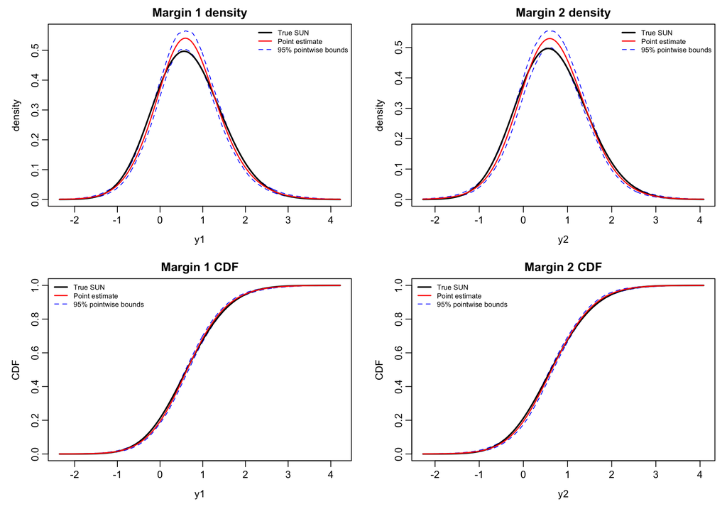

Heavy censoring: fitted marginal densities and CDFs versus the SUN truth. Red: point estimates; black: truth. When sampling is enabled, dashed blue lines show pointwise 95% credible bounds.

```r
plot_mgcv_marginals(fits$Heavy, margin_map, marginal_grids,
  bands = posterior_results$Heavy$bands$marginals)
```

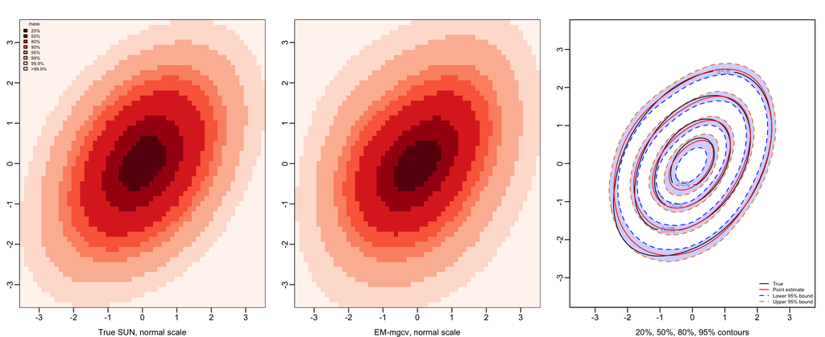

Heavy censoring: normal-score density comparisons. Truth is black and point estimate is red. When sampling is enabled, pointwise 95% lower bounds are dashed blue and upper bounds are dashed orange, with light blue shading between them.

```r
old_par <- par(mfrow = c(1, 3), mar = c(3, 2, 2, 1), mgp = c(2, 0.5, 0))
plot_mgcv_density_pair(views$Heavy$z, views$Heavy$z, views$Heavy$true_normal,
  views$Heavy$normal, c("True SUN, normal scale", "EM-mgcv, normal scale"),
  lower = posterior_results$Heavy$bands$normal$lower,
  upper = posterior_results$Heavy$bands$normal$upper)
```

```r
par(old_par)
```

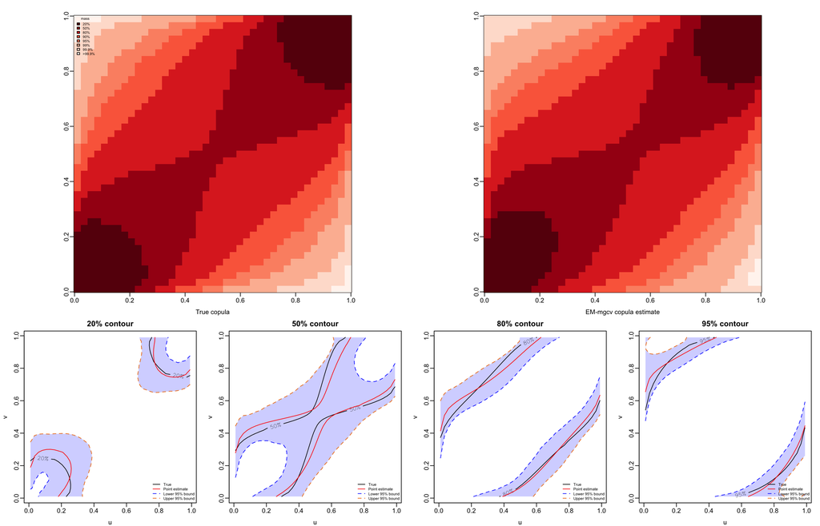

Heavy censoring: copula density maps and separate 20%, 50%, 80%, and 95% contours. Each contour panel shows its own pointwise 95% CI with dashed blue lower bounds, dashed orange upper bounds, and blue shading (alpha = 0.2); point estimates are red and truth is black.

```r
old_par <- par(c("mfrow", "mar", "mgp", "pty"))
layout(rbind(c(1, 1, 2, 2), c(3, 4, 5, 6)), heights = c(1.5, 1))
par(mar = c(3, 3, 2, 1), mgp = c(2, 0.5, 0), pty = "s")
plot_mgcv_density_pair(ug, ug, truth_copula, views$Heavy$copula,
  c("True copula", "EM-mgcv copula estimate"),
  lower = posterior_results$Heavy$bands$copula$lower,
  upper = posterior_results$Heavy$bands$copula$upper, separate_contours = TRUE)
```

```r
par(old_par)
```

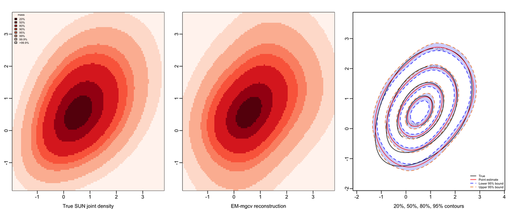

Heavy censoring: true joint density and the reconstruction from fitted marginals and the copula-scale density.

```r
old_par <- par(mfrow = c(1, 3), mar = c(3, 2, 2, 1), mgp = c(2, 0.5, 0))
plot_mgcv_density_pair(eval_x, eval_y, truth_joint, views$Heavy$joint,
  c("True SUN joint density", "EM-mgcv reconstruction"),
  lower = posterior_results$Heavy$bands$joint$lower,
  upper = posterior_results$Heavy$bands$joint$upper)
```

```r
par(old_par)
```

## Intermediate censoring

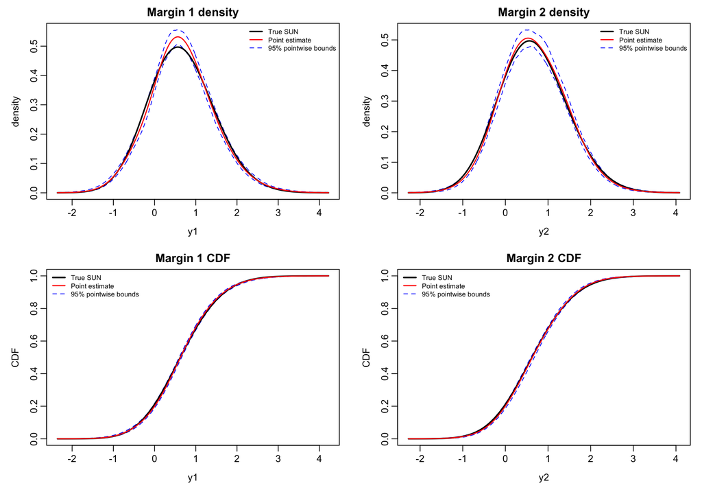

Intermediate censoring: fitted marginal densities and CDFs versus the SUN truth.

```r
plot_mgcv_marginals(fits$Intermediate, margin_map, marginal_grids,
  bands = posterior_results$Intermediate$bands$marginals)
```

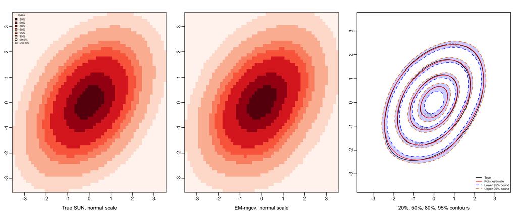

Intermediate censoring: normal-score density comparisons using the same display grid as heavy censoring.

```r
old_par <- par(mfrow = c(1, 3), mar = c(3, 2, 2, 1), mgp = c(2, 0.5, 0))
plot_mgcv_density_pair(views$Intermediate$z, views$Intermediate$z,
  views$Intermediate$true_normal, views$Intermediate$normal,
  c("True SUN, normal scale", "EM-mgcv, normal scale"),
  lower = posterior_results$Intermediate$bands$normal$lower,
  upper = posterior_results$Intermediate$bands$normal$upper)
```

```r
par(old_par)
```

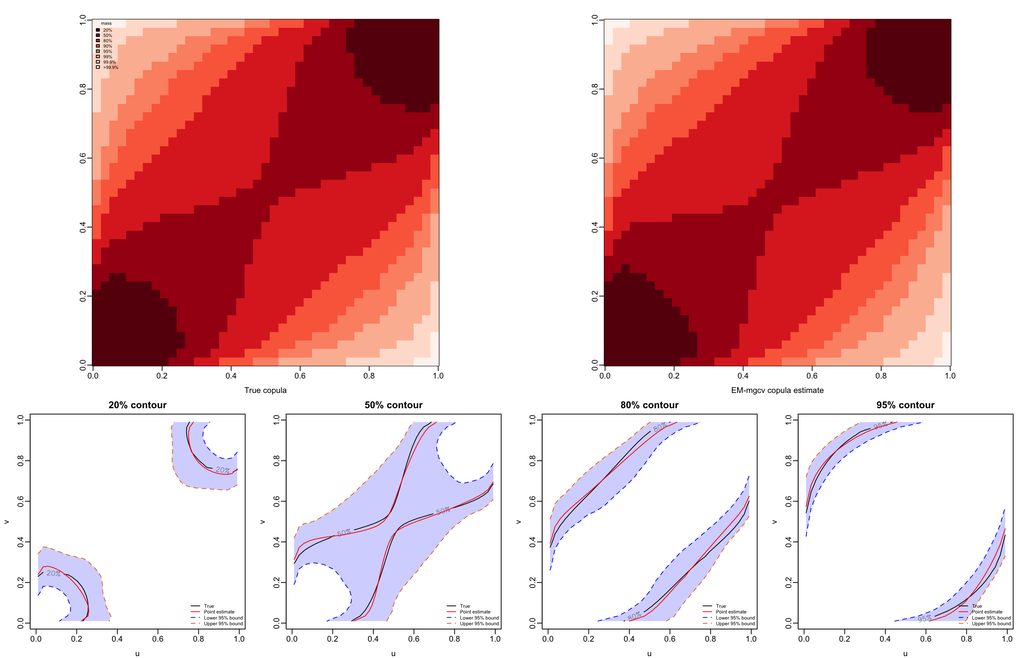

Intermediate censoring: copula density maps and separate 20%, 50%, 80%, and 95% contours, each with its own pointwise 95% CI.

```r
old_par <- par(c("mfrow", "mar", "mgp", "pty"))
layout(rbind(c(1, 1, 2, 2), c(3, 4, 5, 6)), heights = c(1.5, 1))
par(mar = c(3, 3, 2, 1), mgp = c(2, 0.5, 0), pty = "s")
plot_mgcv_density_pair(ug, ug, truth_copula, views$Intermediate$copula,
  c("True copula", "EM-mgcv copula estimate"),
  lower = posterior_results$Intermediate$bands$copula$lower,
  upper = posterior_results$Intermediate$bands$copula$upper, separate_contours = TRUE)
```

```r
par(old_par)
```

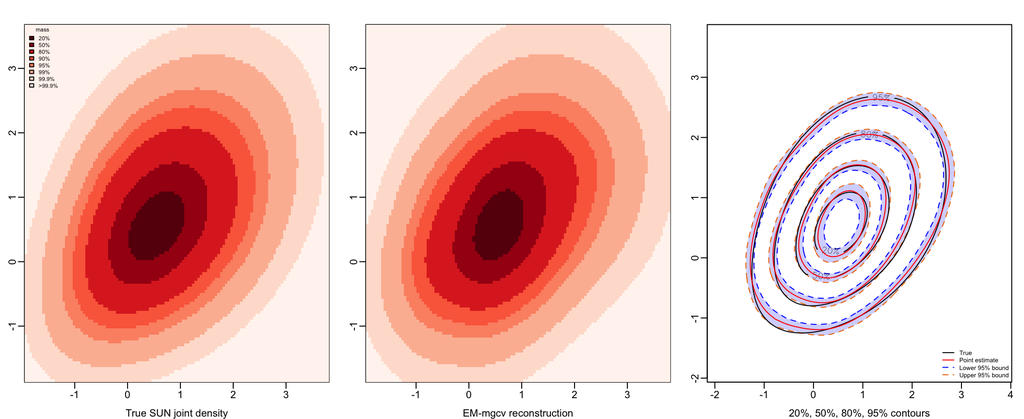

Intermediate censoring: true and reconstructed joint densities.

```r
old_par <- par(mfrow = c(1, 3), mar = c(3, 2, 2, 1), mgp = c(2, 0.5, 0))
plot_mgcv_density_pair(eval_x, eval_y, truth_joint, views$Intermediate$joint,
  c("True SUN joint density", "EM-mgcv reconstruction"),
  lower = posterior_results$Intermediate$bands$joint$lower,
  upper = posterior_results$Intermediate$bands$joint$upper)
```

```r
par(old_par)
```

## Light censoring

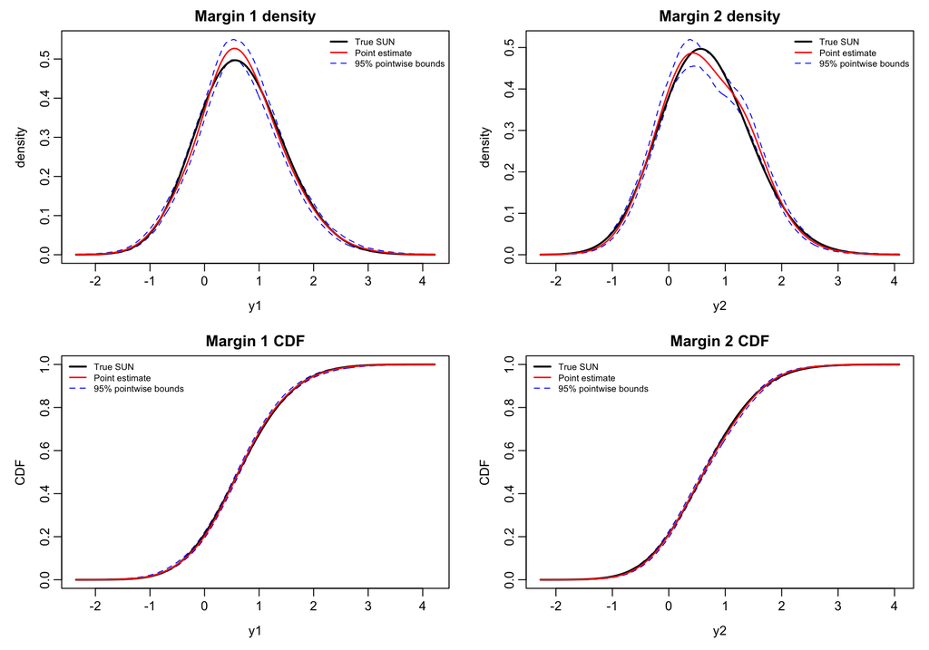

Light censoring: fitted marginal densities and CDFs versus the SUN truth.

```r
plot_mgcv_marginals(fits$Light, margin_map, marginal_grids,
  bands = posterior_results$Light$bands$marginals)
```

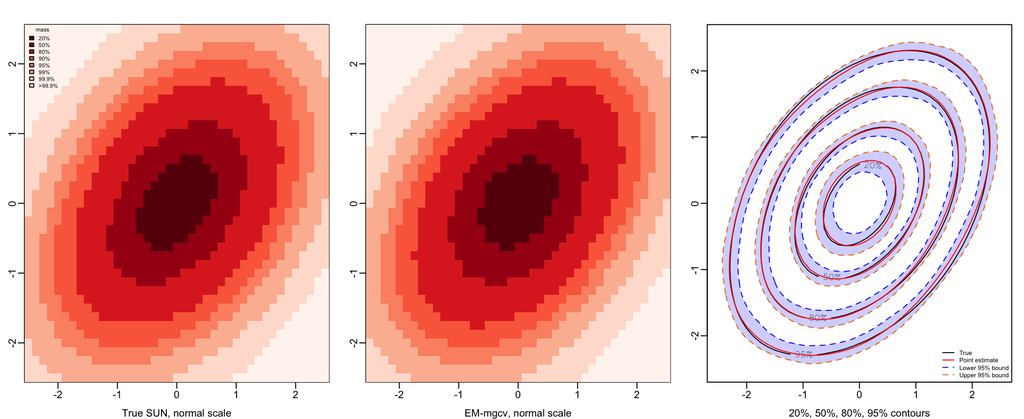

Light censoring: normal-score density comparisons using the reference’s narrower range [-2.5, 2.5].

```r
old_par <- par(mfrow = c(1, 3), mar = c(3, 2, 2, 1), mgp = c(2, 0.5, 0))
plot_mgcv_density_pair(views$Light$z, views$Light$z, views$Light$true_normal,
  views$Light$normal, c("True SUN, normal scale", "EM-mgcv, normal scale"),
  lower = posterior_results$Light$bands$normal$lower,
  upper = posterior_results$Light$bands$normal$upper)
```

```r
par(old_par)
```

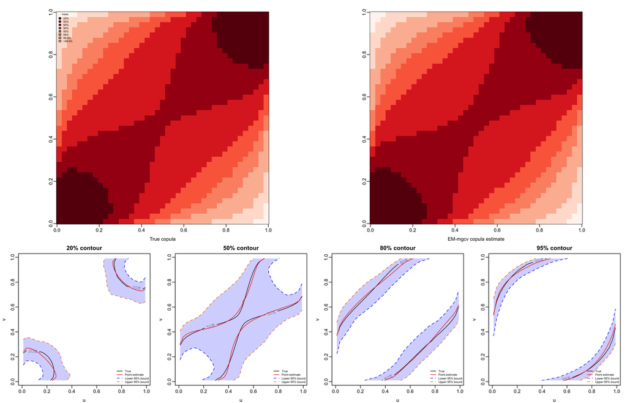

Light censoring: copula density maps and separate 20%, 50%, 80%, and 95% contours, each with its own pointwise 95% CI.

```r
old_par <- par(c("mfrow", "mar", "mgp", "pty"))
layout(rbind(c(1, 1, 2, 2), c(3, 4, 5, 6)), heights = c(1.5, 1))
par(mar = c(3, 3, 2, 1), mgp = c(2, 0.5, 0), pty = "s")
plot_mgcv_density_pair(ug, ug, truth_copula, views$Light$copula,
  c("True copula", "EM-mgcv copula estimate"),
  lower = posterior_results$Light$bands$copula$lower,
  upper = posterior_results$Light$bands$copula$upper, separate_contours = TRUE)
```

```r
par(old_par)
```

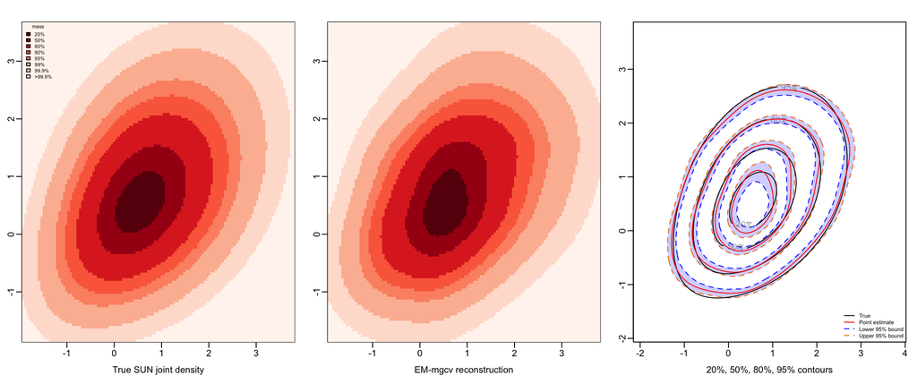

Light censoring: true and reconstructed joint densities.

```r
old_par <- par(mfrow = c(1, 3), mar = c(3, 2, 2, 1), mgp = c(2, 0.5, 0))
plot_mgcv_density_pair(eval_x, eval_y, truth_joint, views$Light$joint,
  c("True SUN joint density", "EM-mgcv reconstruction"),
  lower = posterior_results$Light$bands$joint$lower,
  upper = posterior_results$Light$bands$joint$upper)
```

```r
par(old_par)
```